# Homework 1 - Report

Navarro Calvo, Monica

07 mayo, 2019

To obtain the maximum number of points, use whenever possible:

- the pipeline symbol %>%,
- `dplyr` verbs (see below),
- `kable` to print tables,
- `ggplot` to produce the figures.

| verb | description |  |
| --- | --- | --- |
| `select()` | select columns |  |
| `filter()` | filter rows |  |
| `arrange()` | re-order or arrange rows |  |
| `mutate()` | create new columns |  |
| `summarise()` | summarise values |  |
| `group_by()` | group operations |  |

#### Exercise 1: Setup

**1.a** Install the tidyverse and knitr.

```r
install.packages("tidyverse", repo = "https://cran.r-project.org", quiet = TRUE)
install.packages("knitr", repo = "https://cran.r-project.org", quiet = TRUE)
```

**1.b** Load the `tidyverse`, `knitr`, and set the precision to 2 digits.

```r
library(tidyverse)
library(knitr)
sprintf("%.2f", 2.22222222)
```

```
## [1] "2.22"
```

#### Exercise 2: Edgar Anderson’s Iris Data

In this exercise, you will analyze a well-known `iris` dataset, which you studied in Machine Learning In Business Analytics course. The dataset contains measurements in centimeters of the variables sepal length and width and petal length and width, respectively for each type of iris, namely, setosa, versicolor, and virginica.

**2.a** Load the dataset `iris` and convert it into `tibble`. How many columns does the dataset have? Name data types of these columns.

In the data set we have 5 columns and with the first 4 being numeric variables, while the last one is a factor variable with 3 levels.

```r
library(tibble)
install.packages("kableExtra", repo = "https://cran.r-project.org", quiet = TRUE)
library(kableExtra)

data(iris)
iris <- as.tibble(iris)

sapply(iris, class) %>%
kable(align = 'c', col.names = c("Type")) %>% kable_styling(c("striped","bordered"), full_width = F, position = "center")
```

|  | Type |
| --- | --- |
| Sepal.Length | numeric |
| Sepal.Width | numeric |
| Petal.Length | numeric |
| Petal.Width | numeric |
| Species | factor |

**2.b** Print out only species and its length of a sepal in ascending order. Print out same columns in using descending order of sepal length.

```r
# In ascending order
iris %>%
  select(Species, Sepal.Length) %>%
  arrange(Sepal.Length) %>%
  kable(align = 'c') %>% kable_styling(c("striped","bordered"), full_width = F, position = "center") %>% scroll_box(width = "100%", height = "200px")
```

| Species | Sepal.Length |
| --- | --- |
| setosa | 4.3 |
| setosa | 4.4 |
| setosa | 4.4 |
| setosa | 4.4 |
| setosa | 4.5 |
| setosa | 4.6 |
| setosa | 4.6 |
| setosa | 4.6 |
| setosa | 4.6 |
| setosa | 4.7 |
| setosa | 4.7 |
| setosa | 4.8 |
| setosa | 4.8 |
| setosa | 4.8 |
| setosa | 4.8 |
| setosa | 4.8 |
| setosa | 4.9 |
| setosa | 4.9 |
| setosa | 4.9 |
| setosa | 4.9 |
| versicolor | 4.9 |
| virginica | 4.9 |
| setosa | 5.0 |
| setosa | 5.0 |
| setosa | 5.0 |
| setosa | 5.0 |
| setosa | 5.0 |
| setosa | 5.0 |
| setosa | 5.0 |
| setosa | 5.0 |

[output cut: 120 more lines]

```r
#In descending order
iris %>%
  select(Species, Sepal.Length) %>%
  arrange(desc(Sepal.Length))  %>%
  kable(align = 'c') %>% kable_styling(c("striped","bordered"), full_width = F, position = "center") %>% scroll_box(width = "100%", height = "200px")
```

| Species | Sepal.Length |
| --- | --- |
| virginica | 7.9 |
| virginica | 7.7 |
| virginica | 7.7 |
| virginica | 7.7 |
| virginica | 7.7 |
| virginica | 7.6 |
| virginica | 7.4 |
| virginica | 7.3 |
| virginica | 7.2 |
| virginica | 7.2 |
| virginica | 7.2 |
| virginica | 7.1 |
| versicolor | 7.0 |
| versicolor | 6.9 |
| virginica | 6.9 |
| virginica | 6.9 |
| virginica | 6.9 |
| versicolor | 6.8 |
| virginica | 6.8 |
| virginica | 6.8 |
| versicolor | 6.7 |
| versicolor | 6.7 |
| versicolor | 6.7 |
| virginica | 6.7 |
| virginica | 6.7 |
| virginica | 6.7 |
| virginica | 6.7 |
| virginica | 6.7 |
| versicolor | 6.6 |
| versicolor | 6.6 |

[output cut: 120 more lines]

**2.c** Create a new object `iris_species` and assign to it the `iris` tibble grouped by the type of `Species`. How many entries does each `Species` have?

Each `Species` has 50 entries

```r
iris_species <- group_by(iris, Species)
iris_species %>%
  count(Species)  %>%
  kable(align = 'c') %>% kable_styling(c("striped","bordered"), full_width = F, position = "center")
```

| Species | n |
| --- | --- |
| setosa | 50 |
| versicolor | 50 |
| virginica | 50 |

**2.d** Print out the average sepal’s and petal’s length and width for each species. What can be noticed?

You can notice that the Virginica specie has the biggest Sepal’s, Petal’s lenght and Petal’s Width on average. The Setosa has the biggest Sepal’s Width on average, but at the same time has the smallest Petal’s width on average.

```r
iris_species %>%
  summarise(AvgSepalLen = mean(Sepal.Length, na.rm = TRUE), AvgPetalLen = mean(Petal.Length, na.rm = TRUE), AvgSepalWid = mean(Sepal.Width, na.rm = TRUE), AvgPetalWid = mean(Petal.Width, na.rm = TRUE))  %>%
  kable(align = 'c') %>% kable_styling(c("striped","bordered"), full_width = F, position = "center")
```

| Species | AvgSepalLen | AvgPetalLen | AvgSepalWid | AvgPetalWid |
| --- | --- | --- | --- | --- |
| setosa | 5.006 | 1.462 | 3.428 | 0.246 |
| versicolor | 5.936 | 4.260 | 2.770 | 1.326 |
| virginica | 6.588 | 5.552 | 2.974 | 2.026 |

**2.e** Modify `iris_species` by adding a new column of standardized petal’s length (i.e., you need to subtract a mean value from each observation and divide by standard deviation). Print the maximum values of this new variable for each species.

```r
iris_species %>%
  mutate(standpetallen = (Petal.Length - mean(Petal.Length))/sd(Petal.Length)) %>%
  summarise(Max_Petal_Length = max(standpetallen)) %>%
  kable(align = 'c') %>% kable_styling(c("striped","bordered"), full_width = F, position = "center")
```

| Species | Max_Petal_Length |
| --- | --- |
| setosa | 2.522112 |
| versicolor | 1.787573 |
| virginica | 2.442495 |

**2.f** Using the original `iris` tibble visualize the relation between petal’s length and petal’s width by plotting a scatter chart. Bonus: display a (linear) regression line without confidence intervals.

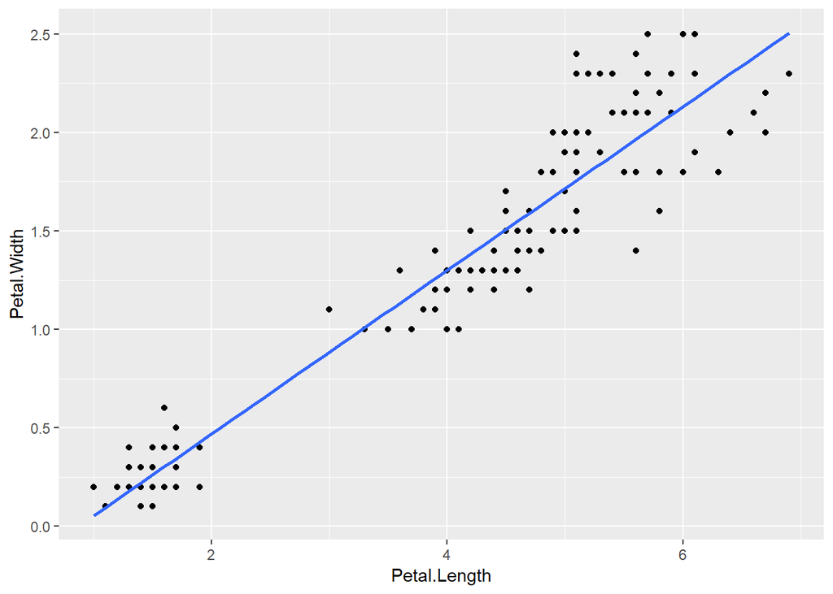

```r
iris %>%
  ggplot(mapping = aes(x=Petal.Length, y=Petal.Width))+
  geom_point() +
  geom_smooth(method='lm', se=FALSE)
```

**2.g** Modify previous plot by using different colors for each species only for the scatter chart and not for the regression line.

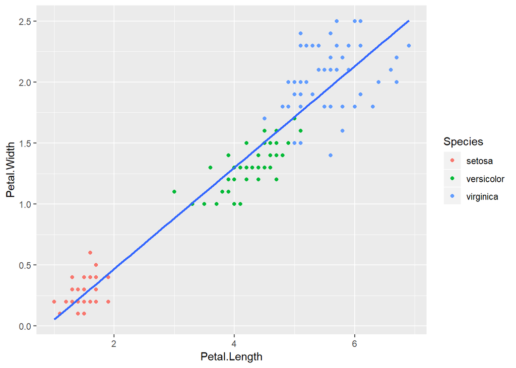

```r
iris %>%
  ggplot(mapping = aes(x=Petal.Length, y=Petal.Width))+
  geom_point(mapping = aes(color = Species)) +
  geom_smooth(method='lm', se=FALSE)
```

#### Exercise 3: House Prices

In this exercise, you will work with the [house prices dataset obtained from Kaggle](https://www.kaggle.com/c/house-prices-advanced-regression-techniques/data). The dataset contains 81 columns describing (almost) every aspect of residential homes in Ames, Iowa.

**3.a** Save the [data file](https://raw.githubusercontent.com/tvatter/dsfba_2019/homework/data/house_prices.csv) in `data` folder of your project. Load the dataset into the global environment by using function `read_csv` and assign it to variable `house_prices`. Make sure that the class of `house_prices` is a tibble.

```r
house_prices <- read_csv("../data/house_prices.csv")
house_prices <- as_tibble(house_prices)
if(is.tibble(house_prices)) "Yes" %>%
  kable(align = 'c', col.names = "Is it a tibble?") %>% kable_styling(c("striped","bordered"), full_width = F, position = "center")
```

| Is it a tibble? |
| --- |
| Yes |

**3.b** You will work with only four variables, namely, `LotArea`, `KitchenQual`, `LotShape`, and `SalePrice`, which indicate area (in square feet), kitchen quality, general shape, and sale price (in dollars) of property. Modify `house_prices` to have only these four columns, as well as transform `LotArea` from square feet into square meters. Bonus: try to use only one `dplyr` function.

```r
house_prices <- transmute(house_prices, LotArea = LotArea*0.092903, KitchenQual = KitchenQual, LotShape = LotShape, SalePrice= SalePrice)

house_prices  %>%
  kable(align = 'c') %>% kable_styling(c("striped","bordered"), full_width = F, position = "center") %>% scroll_box(width = "100%", height = "200px")
```

| LotArea | KitchenQual | LotShape | SalePrice |
| --- | --- | --- | --- |
| 785.0303 | Gd | Reg | 208500 |
| 891.8688 | TA | Reg | 181500 |
| 1045.1588 | Gd | IR1 | 223500 |
| 887.2237 | Gd | IR1 | 140000 |
| 1324.7968 | Gd | IR1 | 250000 |
| 1311.3258 | TA | IR1 | 143000 |
| 936.8339 | Gd | Reg | 307000 |
| 964.5189 | TA | IR1 | 200000 |
| 568.5664 | TA | Reg | 129900 |
| 689.3403 | TA | Reg | 118000 |
| 1040.5136 | TA | Reg | 129500 |
| 1107.7754 | Ex | IR1 | 345000 |
| 1204.7661 | TA | IR2 | 144000 |
| 989.6028 | Gd | IR1 | 279500 |
| 1014.5008 | TA | IR1 | 157000 |
| 568.5664 | TA | Reg | 132000 |
| 1044.3226 | TA | IR1 | 149000 |
| 1002.5163 | TA | Reg | 90000 |
| 1272.3066 | Gd | Reg | 159000 |
| 702.3467 | TA | Reg | 139000 |
| 1320.6161 | Gd | IR1 | 325300 |
| 692.0344 | Gd | Reg | 139400 |
| 905.0610 | Gd | Reg | 230000 |
| 392.4223 | TA | Reg | 129900 |
| 766.0781 | Gd | IR1 | 154000 |
| 1322.0097 | Gd | Reg | 256300 |
| 668.9016 | Gd | Reg | 134800 |
| 1066.3406 | Gd | Reg | 306000 |
| 1516.2699 | TA | IR1 | 207500 |
| 587.5186 | Fa | IR1 | 68500 |

[output cut: 1430 more lines]

**3.c** For how many lots have the sale price was greater than its mean value? For 560

```r
house_prices %>%
  count(SalePrice > mean(SalePrice))  %>%
  kable(align = 'c', col.names = c("Is sale price greater than its mean value?", "Count")) %>% kable_styling(c("striped","bordered"), full_width = F, position = "center")
```

| Is sale price greater than its mean value? | Count |
| --- | --- |
| FALSE | 900 |
| TRUE | 560 |

**3.d** Display the average sale price for each kitchen quality level.

Note, levels of `KitchenQual` correspond to the followin values:

```
- Ex -- Excellent,
- Gd -- Good,
- TA -- Typical/Average,
- Fa -- Fair
- Po -- Poor
```

```r
house_prices %>%
  group_by(KitchenQual) %>%
  summarise(AveSalePrice = mean(SalePrice)) %>%
  arrange(AveSalePrice)  %>%
  kable(align = 'c', col.names = c("Kitchen Quality", "Average Sale Price")) %>% kable_styling(c("striped","bordered"), full_width = F, position = "center")
```

| Kitchen Quality | Average Sale Price |
| --- | --- |
| Fa | 105565.2 |
| TA | 139962.5 |
| Gd | 212116.0 |
| Ex | 328554.7 |

**3.e** Display ten randomly selected observations from the dataset. What happens if you execute your code a few times? How can you make sure that each execution returns the exact 10 rows?

```r
set.seed(45)
sample_n(house_prices, 10) %>%
  kable(align = 'c') %>% kable_styling(c("striped","bordered"), full_width = F, position = "center")
```

| LotArea | KitchenQual | LotShape | SalePrice |
| --- | --- | --- | --- |
| 951.3267 | TA | Reg | 207500 |
| 1113.7212 | TA | IR1 | 188700 |
| 489.6917 | Gd | IR1 | 190000 |
| 557.4180 | TA | Reg | 112500 |
| 845.4173 | TA | Reg | 129900 |
| 1006.9756 | TA | IR1 | 181000 |
| 759.5749 | TA | Reg | 139000 |
| 905.8043 | TA | Reg | 135500 |
| 780.3852 | Gd | Reg | 179500 |
| 964.5189 | TA | IR1 | 200000 |

**3.f** Print out the minimum price of observations for which shape is regular (i.e., `"Reg"`), and the kitchen has excellent quality.

```r
house_prices %>%
  filter(LotShape == "Reg" & KitchenQual == "Ex") %>%
  summarise(MinPrice = min(SalePrice, na.rm = TRUE))  %>%
  kable(align = 'c', col.names = "Minimum price of house with regular lot sixe and excelent kitchen quality") %>% kable_styling(c("striped","bordered"), full_width = F, position = "center")
```

| Minimum price of house with regular lot sixe and excelent kitchen quality |
| --- |
| 86000 |

**3.g** Produce boxplots with kitchen quality as the x-axis and the price as the y-axis. Regroup kitchen quality in the following order: excellent, good, typical/average, and fair. What can you say about the relationship between kitchen quality and the price?

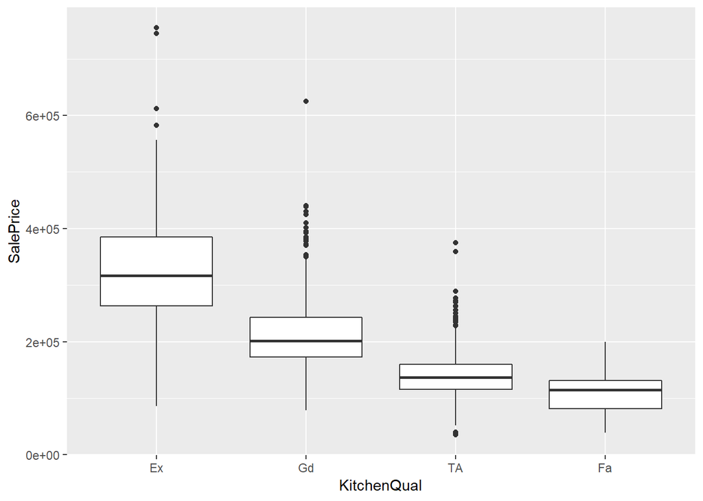

```r
house_prices %>%
  mutate(KitchenQual = fct_relevel(KitchenQual, c("Ex", "Gd", "TA", "Fa"))) %>%
  arrange(KitchenQual) %>%
  ggplot() +
  geom_boxplot(mapping = aes(x = KitchenQual, y = SalePrice))
```

**3.h** Draw a scatter chart to investigate the dependence between `LotArea` and `SalePrice`. Further, use different colors depending on the kitchen quality, and different shapes depending on the shape of the property.

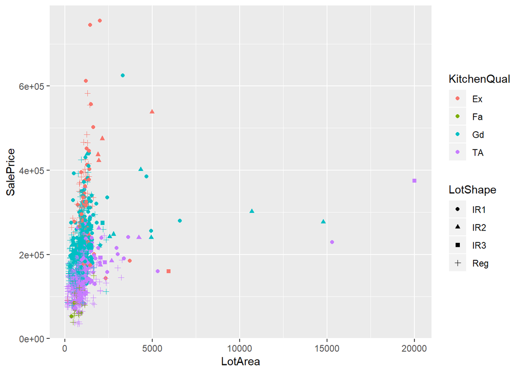

```r
house_prices %>%
  ggplot(aes(x = LotArea, y = SalePrice, color = KitchenQual, shape = LotShape)) +
  geom_point()
```

```r
?ggplot
```